# PA1_Template

Bola Lawal

2022-04-23

```r
knitr::opts_chunk$set(fig.path='Figs/',echo = TRUE)
```

###Activity Monitoring Data ##Install the packages

```r
destination <- getwd()
r = getOption("repos")
r["CRAN"] = "http://cran.us.r-project.org"
options(repos = r)
install.packages("data.table")
```

```r
install.packages("ggplot2")
install.packages("data.table")
install.packages("ggplot2")
```

##Load the libraries

```r
library("data.table")
library("ggplot2")
```

##Load the Data

```r
fileUrl <- "https://d396qusza40orc.cloudfront.net/repdata%2Fdata%2Factivity.zip"
download.file(fileUrl, destfile = paste0(getwd(), '/repdata%2Fdata%2Factivity.zip'), method = "curl")
unzip("repdata%2Fdata%2Factivity.zip",exdir = "destination")
```

#Read the files

```r
activity_data <- data.table::fread(input = "destination/activity.csv")
Number_of_Observations <- nrow(activity_data)
Number_of_Observations
```

```
## [1] 17568
```

##Questions: ##1. Calculate the mean total number of steps taken per day #1.1. Calculate the total number of steps taken per day ##Load the libraries

```r
Total_Steps <- activity_data[, c(lapply(.SD, sum, na.rm = FALSE)), .SDcols = c("steps"), by = .(date)]
head(Total_Steps, 10)
```

```
##           date steps
##  1: 2012-10-01    NA
##  2: 2012-10-02   126
##  3: 2012-10-03 11352
##  4: 2012-10-04 12116
##  5: 2012-10-05 13294
##  6: 2012-10-06 15420
##  7: 2012-10-07 11015
##  8: 2012-10-08    NA
##  9: 2012-10-09 12811
## 10: 2012-10-10  9900
```

#1.2. Histogram of the total number of steps taken per day

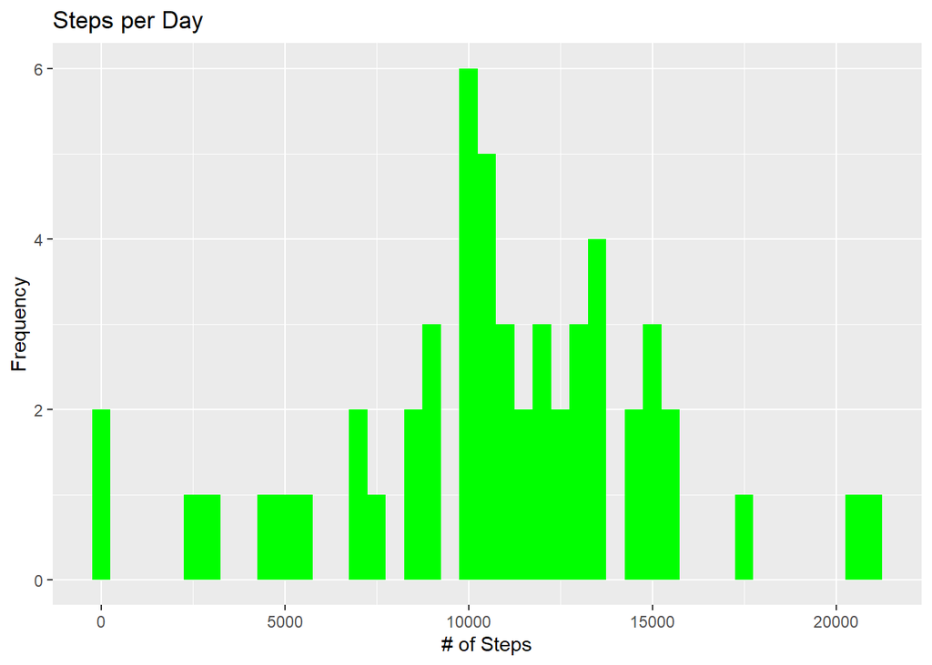

```r
ggplot(Total_Steps, aes(x = steps)) +
  geom_histogram(fill = "green", binwidth = 500) +
  labs(title = "Steps per Day", x = "# of Steps", y = "Frequency")
```

#1.3. Mean and median of the total number of steps taken per day

```r
Total_Steps[, .(Mean_Steps = mean(steps, na.rm = TRUE), Median_Steps = median(steps, na.rm = TRUE))]
```

```
##    Mean_Steps Median_Steps
## 1:   10766.19        10765
```

##2. What is the average daily activity pattern? #2.1. Time series plot

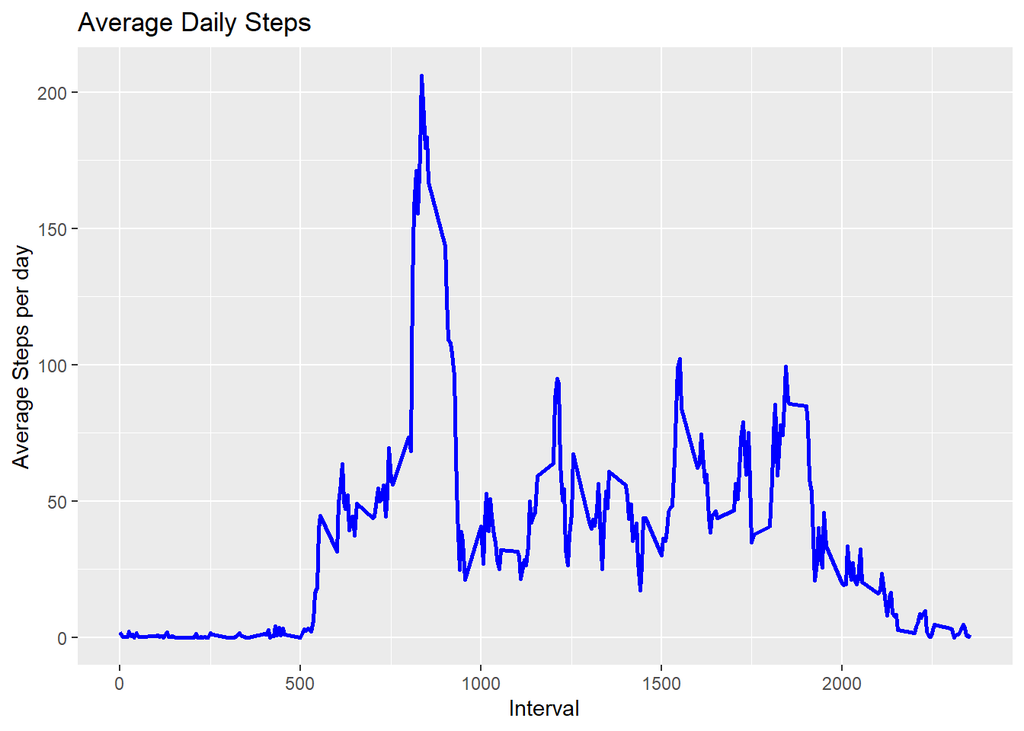

```r
Interval <- activity_data[, c(lapply(.SD, mean, na.rm = TRUE)), .SDcols = c("steps"), by = .(interval)]
ggplot(Interval, aes(x = interval , y = steps)) + geom_line(color="blue", size=1) + labs(title = "Average Daily Steps", x = "Interval", y = "Average Steps per day")
```

#2.2. 5-minute interval, on average across all the days in the dataset with the maximum number of steps

```r
Interval[steps == max(steps), .(max_interval = interval)]
```

```
##    max_interval
## 1:          835
```

##3. Inputting missing values #3.1 Calculate and report the total number of missing values in the dataset

```r
nrow(activity_data[is.na(steps),])
```

```
## [1] 2304
```

#3.2. Devise a strategy for filling in all of the missing values in the dataset. #Strategy used is to find the mean of the existing values.

```r
activity_data[is.na(steps), "steps"] <- activity_data[, c(lapply(.SD, mean, na.rm = TRUE)), .SDcols = c("steps")]
```

#3.3. Create a new dataset that is equal to the original dataset but with the missing data filled in.

```r
data.table::fwrite(x = activity_data, file = "destination/No_NULL.csv", quote = FALSE)
```

##4. General Questions: #Make a histogram of the total number of steps taken each day. #Calculate and report the mean and median total number of steps taken per day. #Do these values differ from the estimates from the first part of the assignment? #What is the impact of inputing missing data on the estimates of the total daily number of steps?

#4.1 Total number of steps taken per day

```r
Total_Steps <- activity_data[, c(lapply(.SD, sum)), .SDcols = c("steps"), by = .(date)]
```

#4.2 Mean and median total number of steps taken per day

```r
Total_Steps[, .(Mean_Steps = mean(steps), Median_Steps = median(steps))]
```

```
##    Mean_Steps Median_Steps
## 1:   10751.74        10656
```

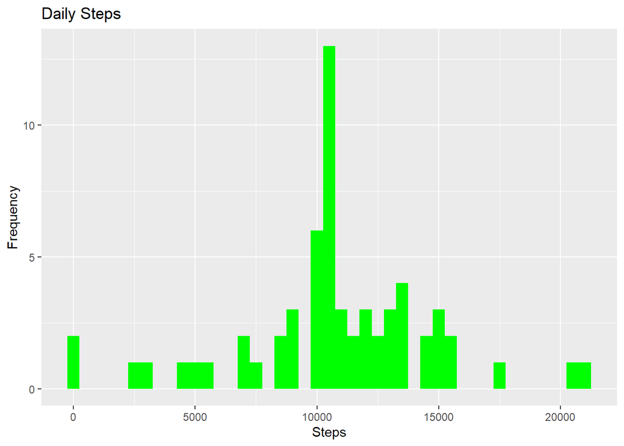

```r
ggplot(Total_Steps, aes(x = steps)) + geom_histogram(fill = "green",binwidth = 500) + labs(title = "Daily Steps", x = "Steps", y = "Frequency")
```

#4.3 # Mean_Steps Median_Steps #1: 10766.19 10765 #2: 10751.74 10656

##5.Are there differences in activity patterns between weekdays and weekends?

```r
activity_data_week <- data.table::fread(input = "destination/activity.csv")
activity_data_week[, date := as.POSIXct(date, format = "%Y-%m-%d")]
activity_data_week[, `Day of Week`:= weekdays(x = date)]
activity_data_week[grepl(pattern = "Monday|Tuesday|Wednesday|Thursday|Friday", x = `Day of Week`), "Weekday/Weekend"] <- "Weekday"
activity_data_week[grepl(pattern = "Saturday|Sunday", x = `Day of Week`), "Weekday/Weekend"] <- "Weekend"
activity_data_week[, `Weekday/Weekend` := as.factor(`Weekday/Weekend`)]
```

#5.1 A panel plot containing a time series plot (i.e. type = “𝚕”) of the 5-minute interval (x-axis) and the average number of steps taken, averaged across all weekday days or weekend days (y-axis).

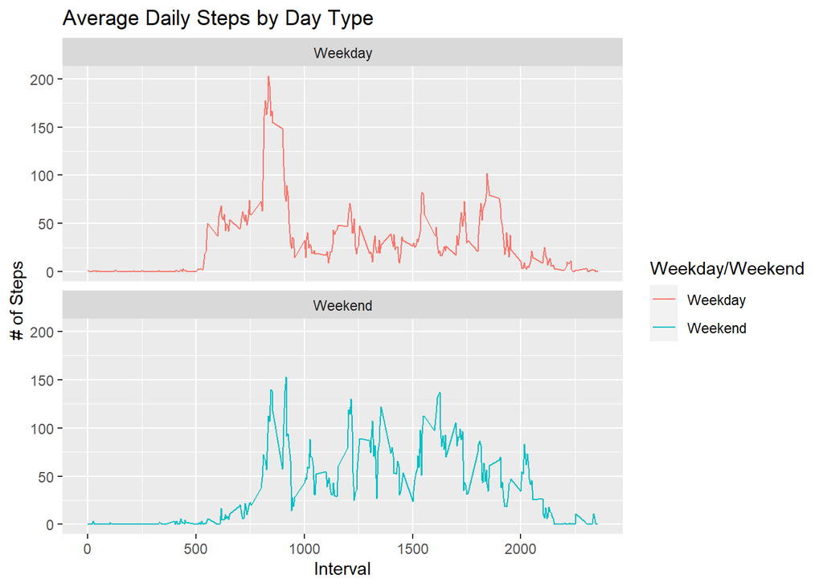

```r
activity_data_week[is.na(steps), "steps"] <- activity_data_week[, c(lapply(.SD, median, na.rm = TRUE)), .SDcols = c("steps")]
Interval <- activity_data_week[, c(lapply(.SD, mean, na.rm = TRUE)), .SDcols = c("steps"), by = .(interval, `Weekday/Weekend`)]
ggplot(Interval , aes(x = interval , y = steps, color=`Weekday/Weekend`)) + geom_line() + labs(title = "Average Daily Steps by Day Type", x = "Interval", y = "# of Steps") + facet_wrap(~`Weekday/Weekend` , ncol = 1, nrow=2)
```